# Inference and Causality

73-374 Econometrics II

## Today

- Heteroskedasticity
- Intro to Causality and Experiments

## Inference with minimal assumptions

- Recall linear model assumptions
1. In population, $y=\beta_0+\beta_{1}x_{1}+\beta_{2}x_{2}+\ldots+\beta_{k}x_{k}+u$
2. ${(y_i,\mathbf{x}_i^\prime):i=1 \ldots n}$ are independent random sample of observations following 1
3. There are no exact linear relationships among the variables $x_0 \ldots x_k$
- Formulas for inference required additional assumptions
  - 4. $E(u|\mathbf{x})=0$
  - 5. **Homoskedasticity** $Var(u|x)=\sigma^2$ a constant $>0$
- Saw last class that (4) can fail with nonlinear conditional expectations
  - Replace by (4’) $E(u\mathbf{x})=0$ : OLS is best linear predictor
- Removing (5) or both (4) and (5), what can we say about inference?

## Data exhibiting linearity but heteroskedasticity (code)

```r
#Generate a data set
x<-runif(1000, min=1, max=7)
u<-rnorm(1000)*(4*x) #u is a function of x
y<-1+4*x+u
#Fit linear regression
hetreg<-lm(y ~ x)
#Plot points and OLS best fit line
plot(x,y,xlab = "x", ylab = "y",
     main = "Heteroskedastic Linear Relationship")
abline(hetreg, col = "blue", lwd=2)
```

## Data exhibiting linearity but heteroskedasticity

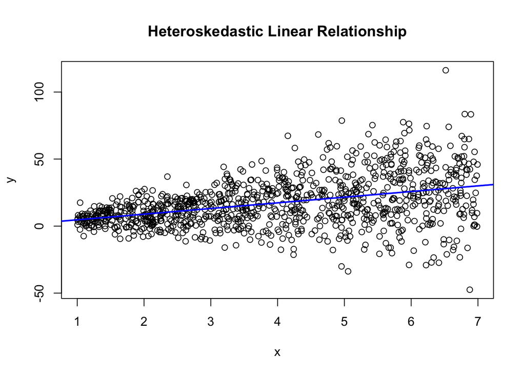

## Data exhibiting nonlinear conditional expectation (code)

```r
#Generate a data set
x<-runif(1000, min=1, max=7)
u<-6*rnorm(1000) #u is not a function of x
y<-1+4*x+5*cos(3*x)+u
#Fit linear regression
hetreg2<-lm(y ~ x)
#Plot points and OLS best fit line
plot(x,y,xlab = "x", ylab = "y",
     main = "Misspecified Relationship")
abline(hetreg2, col = "blue", lwd=2)
curve(1+4*x+5*cos(3*x),add=TRUE,col="red",lwd=2)
```

## Data exhibiting nonlinear conditional expectation

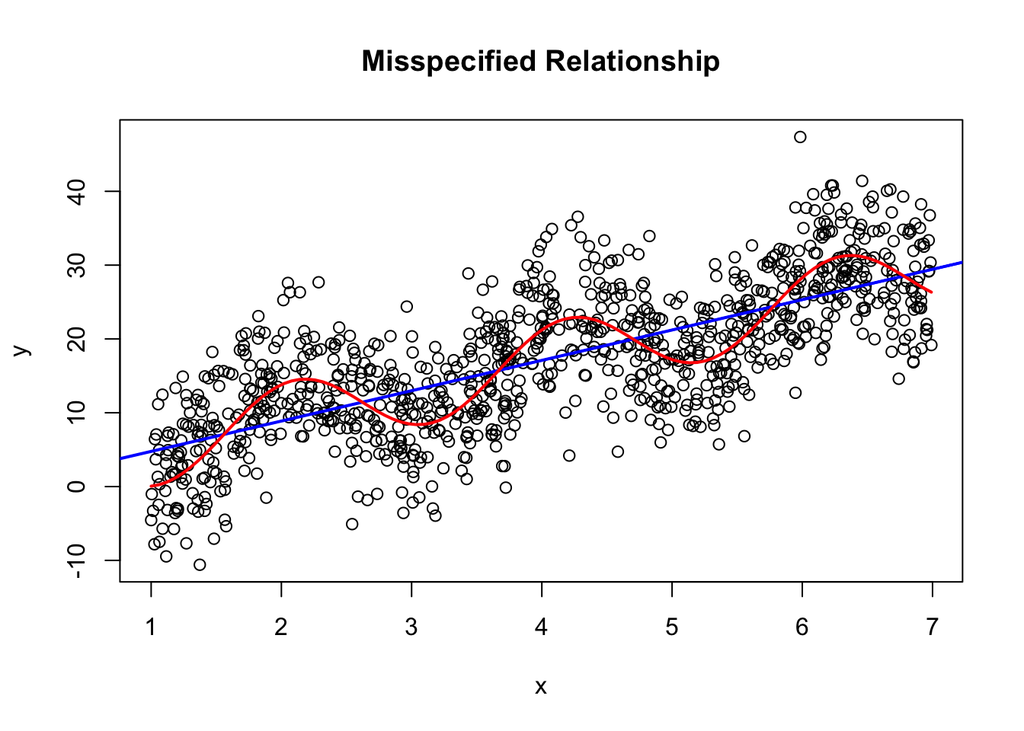

## Implications of heteroskedasticity

- Conditional distribution of y given x now varies
  - $Var(u|\mathbf{x}):=\sigma^2(\mathbf{x})$
- Gauss Markov assumptions fail, OLS is not MLE
- OLS no longer efficient
- But method of moments interpretation still works
- We still have consistency: can we do inference?
  - Yes, CLT still holds, with different variance
  - Need new variance estimator to make tests/CIs

## Limit Distribution under Heteroskedasticity: Univariate Case

- Under linearity
  $$\hat{\mathbf{\beta}_{1}}:=\beta_1+ \frac{\sum_{i=1}^{n}(\mathbf{x}_{i}-\bar{x})u_i}{\sum_{i=1}^{n}(\mathbf{x}_{i}-\bar{x})^2}$$
- Rescale by $\sqrt{n}$ to get
  $$\sqrt{n}(\hat{\mathbf{\beta}}-\beta)= \frac{\frac{1}{\sqrt{n}}\sum_{i=1}^{n}(\mathbf{x}_{i}-\bar{x})u_i}{\frac{1}{n}\sum_{i=1}^{n}(\mathbf{x}_{i}-\bar{x})^2}$$
- Apply CLT, LLN, obtain
  $$\sqrt{n}(\hat{\beta}_{1}-\beta_{1})\overset{d}{\rightarrow}N(0,\Sigma_{11})$$
- $$\Sigma_{11}:=\frac{E[u_{i}^2(x_{i}-E[x_{i}])^2]}{Var^2(x_i)}$$

## Eicker-Huber-White Robust Standard Errors

- $$\Sigma_{11}=\frac{E[u_{i}^2(x_{i}-E[x_{i}])^2]}{Var^2(x_i)}=\frac{E[E[u_{i}^2|\mathbf{x}](x_{i}-E[x_{i}])^2]}{Var^2(x_i)}$$
- Replace means by sample averages to get estimate
- Estimated errors consistent without exact linearity or homoskedasticity
- Gives valid (approximate) CIs, tests, etc under (1-3), (4’)
- Works whether linear or not, homoskedastic or not, hence “robust”
- Multivariate case similar, see bonus slides
- Implemented in **R** using **sandwich** command

## Wage predictions with and without robust SEs (Code 1)

```r
# Obtain access to data sets used in our textbook
library(foreign)
#Load library to make pretty table
library(stargazer)
# Import data set of education and wages
wage1<-read.dta(
  "http://fmwww.bc.edu/ec-p/data/wooldridge/wage1.dta")
# Regress log wage on years of education and experience
wageregression2 <- lm(formula = lwage ~ educ +
                  exper, data = wage1)
#Load library to calculate Robust SEs
library(sandwich)
# Calculate heteroskedasticity-consistent (HC) estimate
Sigmahat<-vcovHC(wageregression2,type="HC0")
#type chooses scaling with some degrees of freedom
#correction: exact choice doesn't matter in large samples
```

## Wage predictions with and without robust SEs (Code 2)

```r
#Load library to implement tests
library(lmtest)
# Test coefs using robust s.e.s
robustwagereg<-coeftest(wageregression2,
              df=Inf,vcov=Sigmahat)
# df=Inf means use critical values from Normal
# distribution, equivalent to t dist with
# infinite degrees of freedom)

#Plot comparison
stargazer(wageregression2,robustwagereg,
    type="html",
    header=FALSE,omit.stat=c("adj.rsq","ser","F"),
    font.size="tiny",digits=5,column.labels =
    c("Homoskedastic Error Formula",
      "Heteroskedastic Error Formula"),
    model.names=FALSE,
    title="Wage Regression with SE Estimates")
```

## Wage predictions with and without robust SEs

**Wage Regression with SE Estimates**

|  | *Dependent variable:* |  |
| --- | --- | --- |
|  | lwage |  |
|  | Homoskedastic Error Formula | Heteroskedastic Error Formula |
|  | (1) | (2) |
| educ | 0.09794*** | 0.09794*** |
|  | (0.00762) | (0.00807) |
| exper | 0.01035*** | 0.01035*** |
|  | (0.00156) | (0.00160) |
| Constant | 0.21685** | 0.21685* |
|  | (0.10860) | (0.11418) |
| Observations | 526 |  |
| R<sup>2</sup> | 0.24934 |  |
| *Note:* | p<0.1; p<0.05; p<0.01 |  |

## Hypotheses tests under heteroskedasticity

- For individual coefficients $\frac{\hat{\beta}_j-\beta_j}{\hat{S.E.}_{robust}}\overset{d}{\rightarrow}N(0,1)$
- Can use standard t-statistic and test with modified standard error estimate
- R commands: **SE<-vcovHC(regression)** produces standard errors, **coeftest(regression,vcov=SE,df=inf)** produces tests and p-values
- For testing multivariate restrictions, F-test no longer valid
- As an alternative, can use *Wald test* statistic $W_n$
- $W_n$ is a sum of squares of unrestricted coefficients $\hat{\beta}$ weighted by $\hat{\Sigma}_{robust}$
  - See bonus slides for exact formula
  - If robust variance replaced by nonrobust variance, equivalent to F-test
- Under $H_0$ with $q$ linear restrictions, $W_n\overset{d}{\rightarrow}\chi^2_q$
  - “Chi-squared distribution with q degrees of freedom”
- R command: **waldtest** in library **lmtest** or **linearHypothesis** in library **car**

## Causality

- Probability is language of things that happen
  - When X happens, Y also happens
- Causality is the language of things that could happen, if something were different
  - If I do X, Y will happen
- Difference is between
  - Factual outcomes: there is some process in the world which leads to data X and Y
  - Counterfactual outcomes: replace the process generating X with a new process
- Example
  - When gas is expensive, people drive less
  - If we raise the tax on gasoline, people will drive less

## Education Example again

- Saw in classes 1-3 that people with more education tend to have higher wages
- Causal question: if I decide to get more education, will it raise my wages?
- If you could observe yourself (or people just like you) who were made to study more and not study more, you could compare
- This is idea behind **experiments**
  - To see what happends when you change something, change it!

## Notation

- Already have notation for factual outcomes: probability
  - $X$ and $Y$ drawn from joint distribution $P(X,Y)$
  - This can be rewritten as $P(Y|X)P(X)$ by conditional probability
- Need new notation for counterfactual outcomes: what happens to $Y$ if we do $X$, i.e. replace the process generating $X$ with $X$ set at some particular value $x$
  - $Y^x$ is *potential outcome*: value of what $Y$ would be in world where $X$ set to $x$
  - Distribution $P(Y^x)$ of $Y^x$ called $P(Y|do(X=x))$
  - This may or may not coincide with $P(Y|X=x)$, observed distribution of $Y$ in situations when $X=x$

## Causal Models

- How do $P(Y|X=x)$ and $P(Y|do(X=x))$ relate?
- We need a model of the world
  - There are many things in the world that happen, some of which correspond to causal actions: some variable sets the value of some other variable at some level
- A model which describes these is called “structural” or “causal”
- Such a model will consist of equations specifying $P(Y|do(X=x))$ for different sets of variables $X$ and $Y$, up to a set of *parameters* $\theta$
- Model will also specify distribution over *observed* events $P(Y,X;\theta)$ given underlying causal structure
- Main task of causal inference is **identification**
- Given $P(Y,X)$ recover (some information about) the parameters $\theta$ of the causal model

## A Randomized Experiment

- Consider data generated by an **experiment**, in which $X$ is set by the experimenter randomly, drawn from a distribution $P(X)$ independently from all other variables related to outcome $Y$
- $Y$ is the *outcome variable*, $X$ is called the *treatment*
- Suppose we model what $Y$ *would* be if $X$ set to $x$ as
  $$Y^x=f(x,U)$$
- $U\sim P_U(U)$ describes all variables other than $X$ affecting $Y$
- Because set by experimenter, $X\sim P_X(X)$ with $X\perp U$
  - This implies $X\perp Y^x$
- Finally, assume *causal consistency* $Y=Y^X$
  - Observed outcome is what it would be if we set $X$ to its observed value
- The *parameters* of model are $f(.,.)$, $P_X(X)$, and $P_U(U)$

## Identifying Causal Effects

- Assume in above model we observe $P(Y,X)$
  - $U$ is an *unobserved* or *latent* variable
- In this model,
  $$P(Y<z|X=x)=P(Y^X<z|X=x)$$
  $$=P(Y^x<z)$$
  $$=P_U(f(x,U)<z)$$
- Line 1 by causal consistency, line 2 by independence, and line 3 by our structural model
- $P(X)=\int P(Y,X)dY$ and $P(Y|X)=\frac{P(Y,X)}{P(X)}$ come from data
- $P(Y^x)$ is identified: can write it as a function of $P(Y,X)$
- Experiments allow us to learn something about causal effects

## Going from identification to estimation

- Above result says that if we knew $P(Y,X)$ in experimental population, could get distribution of potential outcomes
- To learn $P(Y,X)$ need to estimate it
- Need 2 additional assumptions
- We have a (large) random sample drawn from population where counterfactual distributions are the same
  - “external validity”: experimental setting should correspond to setting of interest
- Observations should be independent, to satisfy L.L.N.
  - Requires “No Interference” between units
  - One person’s job training shouldn’t affect another’s wages

## What we can’t learn from experiments

- Experiments can tell us distribution of potential outcomes $Y^x$ for all $x$ studied
- This is not all we might want to know
  - Without observing other variables $U$ or knowing something about $f(.,.)$, can’t say much about effects of $U$
  - We don’t manipulate $U$ so we can’t say what its effect is
- Usually can’t learn *realization* of $Y^x$ for $X\neq x$
  - Know its distribution, but not its value
- E.g.: can never learn what would happen to **you** if you got more education, just distribution of what could happen

## Non-experimental data

- Without explicit causal assignment, much less believable that $X$ is unrelated to other variables affecting $Y$
- Maybe unobserved variable causes $Y$ and $X$ or $Y$ and $X$ both cause unobserved variable
- Can still write $Y^x=f(x,U)$ and $Y=Y^X$
- But now, instead of $X$ set at a particular value, have some process generating a joint distribution
  $$(X,U)\sim P(X,U)$$
  not in general independent
- In general $P(Y|X)\neq P(Y|do(X))$
- Ex: P(Y=Rain today|X=people carrying umbrellas) is increasing function in X, but P(Rain|do(carry an umbrella)) is constant in X

## Special case: binary treatment

- Let $X\in{0,1}$ be the treatment whose effect we want to measure
- Model $Y^x=f(x,U)$ can now be expressed as $Y^0:=f(0,U)$, $Y^1:=f(1,U)$
- Each unit $i$ sampled has values $Y_i^0=f(0,U_i)$ and $Y_i^1:=f(1,U_i)$
- **Treatment effect** for $i$ is defined as $Y_i^1-Y_i^0$
- Causal consistency says observations given by $Y_i=Y_i^0 1\{X_i=0\}+Y_i^1 1\{X_i=1\}$
- Only observe actual outcome $Y_i^{X_i}$, never counterfactual outcome $Y_i^{1-X_i}$
- Fundamental problem of causal inference
  - Only see what was, not what might have been

## Learning about treatment effects

- Usually interested in learning about features of distribution of treatment effects
- Parameter of interest:
  - **Average Treatment Effect** (ATE) $E[Y_i^1-Y_i^0]$
- Let’s see why this is hard to learn about
- Consider naïve comparison: difference in conditional means $E[Y_i|X_i=1]-E[Y_i|X_i=0]$
- If we have a sample of a population $(Y_i,X_i)$ with $n_0$ units with $X_i=0$ and $n_1$ with $X_i=1$, we can construct estimate of this by
  $$\frac{1}{n_1}\sum_{i=1}^{n}Y_i 1\{X_i=1\}-\frac{1}{n}\sum_{i=1}^{n_0}Y_i 1\{X_i=0\}$$

## Bias in naïve estimate of causal effects

$$E[Y_i|X_i=1]-E[Y_i|X_i=0]=E[Y_i^1|X_i=1]-E[Y_{i}^{0}|X_i=0]$$
Add and subtract $E[Y_i^0|X_i=1]$
$$=\stackrel{\text{ATT}}{E[Y_i^1-Y_i^0|X_i=1]}+\stackrel{\text{"selection bias"}}{(E[Y_i^0|X_i=1]-E[Y_i^0|X_i=0])}$$

- First term is **ATT** “average treatment effect on the treated”
  - For those assigned to treatment group, causal effect of the treatment
  - May differ from ATE if treatment assigned to groups for whom efficacy differs
- Second term is **selection bias**
  - Difference in baseline outcome levels between group selected for treatment and group not selected
  - Nonzero if treatment and control group systematically differ in ways relevant to the outcome

## Example: Job Training and Earnings

- US runs many job training programs for low skill workers
- Goal is to get them back from bad economic situation to find higher-paying work
- Is training effective? Hard to tell
  $$E[\text{earnings|training}]-E[\text{earnings|no training}]=$$
  $$E[\text{earnings change|do(training),trained}]+$$
  $$(E[\text{untrained earnings|trained}]-E[\text{untrained earnings|not trained}])$$
- Want to know effectiveness of program
- First term gives this, at least for participants
- Problem is, second term is probably very negative
  - People get job training because they have a bad job, or no job at all
  - On average, those who get training are those with lower untrained earnings

## Experiments and treatment effects

- Suppose treatment assigned randomly: $(Y_i^0,Y_i^1) \perp X_i$
- Independence means conditional distributions same as unconditional
- Selection bias now
  $$E[Y_i^0|X_i=1]-E[Y_i^0|X_i=0]=E[Y_i^0]-E[Y_i^0]=0$$
- ATT now
  $$E[Y_i^1-Y_i^0|X_i=1]=E[Y_i^1-Y_i^0]=\text{ATE}$$
- By L.L.N. Difference in means consistently estimates ATE for randomized experiments
- In small samples, estimate not exact
  - May have drawn sample where $U_i$ differ between treatment and control groups

## Random coefficients

- Write potential outcomes model in more familiar form
  $$Y_i=Y_i^0+(Y_i^1-Y_i^0)X_i$$
- Define $\beta_{0,i}=Y_i^0$, $\beta_{1,i}=Y_i^1-Y_i^0$, then
  $$Y_i=\beta_{0,i}+\beta_{1,i}X_i$$
- Slope is treatment effect, intercept is value if not treated
- Result is a linear model with *random coefficients*
- Like linear model, but slope terms no longer constant

## Relating to standard linear model

- Taking averages, can write as
  - $\beta_{0,i}:=\bar{\beta}_0+e_{0i}$
  - $\beta_{1,i}:=\bar{\beta}_1+e_{1i}$
  - $E[e_{0i}]=E[e_{1i}]=0$
- Random coefficients model becomes
  $$Y_i=\bar{\beta}_0+\bar{\beta}_1X_i+e_{0i}+X_ie_{1i}$$
- A standard linear model with heteroskedastic errors
- Slope coefficient $\bar{\beta}_1$ is ATE
- *Endogeneity*: under nonrandom assignment, residual may be correlated with $X_i$

## Estimation

- If X assigned randomly, $X_i\perp e_{0i}$ (no selection bias) and $X_i\perp e_{1i}$ (treatment effect independent of treatment assignment)
- Model becomes standard linear model satisfying Assumptions (1-4)
- $\hat{\beta}_1$ OLS estimator same as difference in means
- Heteroskedasticity: residual $e_{0i}+X_ie_{1i}$ has variance which depends on $X$ so long as $e_{1i}\neq 0$ (“heterogeneous treatment effects”)
- OLS with robust standard errors gives valid inference on ATE for experimental data
- Equivalent to two-sample t-test on difference in means with unequal variances

## Next class

- Examples
- Causality in multivariate setting
- Read Angrist Chapter 2

## (Bonus 1): Standard errors under heteroskedasticity

- Recall Multivariate OLS formula
  $$\hat{\mathbf{\beta}}:=\beta+ (\sum_{i=1}^{n}\mathbf{x}_{i}\mathbf{x}_{i}^\prime)^{-1}\sum_{i=1}^{n}\mathbf{x}_{i}u_i$$
- Rescale by $\sqrt{n}$ to get
  $$\sqrt{n}(\hat{\beta}-\beta)=(\frac{1}{n}\sum_{i=1}^{n}\mathbf{x}_{i}\mathbf{x}_{i}^\prime)^{-1}\frac{1}{\sqrt{n}}\sum_{i=1}^{n}\mathbf{x}_{i}u_i$$
- Second part of second term looks like sum used in CLT
- It has mean $E[\mathbf{x}_{i}u_{i}]=0$ and variance $E[u_{i}^2\mathbf{x}_{i}\mathbf{x}_{i}^{\prime}]$
- This equals $E[E[u_{i}^2\mathbf{x}_{i}\mathbf{x}_{i}^{\prime}|\mathbf{x}]]=E[E[u_{i}^2|\mathbf{x}]\mathbf{x}_{i}\mathbf{x}_{i}^{\prime}]$

## (Bonus 2) Limiting variance

- Above results and CLT imply
  $$\frac{1}{\sqrt{n}}\sum_{i=1}^{n}\mathbf{x}_{i}u_i\overset{d}{\rightarrow}N(0,E[E[u_{i}^2|\mathbf{x}]\mathbf{x}_{i}\mathbf{x}_{i}^{\prime}])$$
- By L.L.N., (3), and continuity $\text{plim}(\frac{1}{n}\sum_{i=1}^{n}\mathbf{x}_{i}\mathbf{x}_{i}^\prime)^{-1}=(E[\mathbf{x}_{i}\mathbf{x}_{i}^\prime])^{-1}$
- Next, if M is a $k+1\times k+1$ matrix and $v$ is a $k+1\times 1$ random vector, fact that $Var(ax+by)=a^{2}Var(x)+b^{2}Var(y)+2abCov(x,y)$ plus mechanics of matrix multiplication imply $Var(Mv)=MVar(v)M^{\prime}$
- Slutsky’s theorem: if $\hat{a}\overset{p}{\rightarrow}a$ a constant and $\hat{b}\overset{d}{\rightarrow}b$ a random variable, then $(\hat{a},\hat{b})\overset{d}{\rightarrow}(a,b)$

## (Bonus 3) Sandwich formula

- The above results imply
  $$\sqrt{n}(\hat{\beta}-\beta)\overset{d}{\rightarrow}N(0,\Sigma)$$
- where
  $$\Sigma:=(E[\mathbf{x}_{i}\mathbf{x}_{i}^\prime])^{-1}E[E[u_{i}^2|\mathbf{x}]\mathbf{x}_{i}\mathbf{x}_{i}^{\prime}](E[\mathbf{x}_{i}\mathbf{x}_{i}^\prime])^{-1}$$
- “Sandwich” formula since outer terms are the same
- Replace expectations by averages, $u_i$ by $\hat{u}_{i}$ to get estimates